# Aplicacoes no software R

# 5 Exercício: deduzir por que a formula da correlação também pode ser escrita assim

## 5.1 calcular Correlação usando os dados da abundância do Coral

```r
dados$Coral
```

```
##  [1] 26.808115  4.159997  1.764783 17.028646 30.322157  9.244251 58.859536
##  [8]  4.524673 28.937399 18.528703 11.399113 22.778681  7.824072 11.532551
```

## 5.2 calcular Correlação usando os dados da abundância do Fire Coral

```r
dados$Fire.Coral
```

```
##  [1] 0.89457449 0.07558747 0.00000000 1.18240389 0.00000000 0.40299228
##  [7] 0.00000000 0.48596548 1.55173210 1.59959290 0.00000000 0.07936556
## [13] 0.00000000 1.32481506
```

```r
mean.coral <- mean(dados$Coral)
mean.Fcoral <- mean(dados$Fire.Coral)

A <- (dados$Coral-mean.coral)
B <- (dados$Fire.Coral-mean.Fcoral)

numerador <- sum(A*B)

C <- sum(A^2)
D <- sum(B^2)

denominador <- sqrt(C*D)

numerador/denominador
```

```
## [1] 0.03477974
```

```r
r_Coral_FireCoral <- sum((dados$Coral-mean.coral)*(dados$Fire.Coral-mean.Fcoral))/(sqrt(sum((dados$Coral-mean.coral)^2))*sqrt(sum((dados$Fire.Coral-mean.Fcoral)^2)))


A
```

```
##  [1]   8.6857809 -13.9623370 -16.3575514  -1.0936879  12.1998232  -8.8780829
##  [7]  40.7372015 -13.5976611  10.8150650   0.4063689  -6.7232208   4.6563465
## [13] -10.2982619  -6.5897828
```

```r
B
```

```
##  [1]  0.35192955 -0.46705747 -0.54264494  0.63975894 -0.54264494 -0.13965267
##  [7] -0.54264494 -0.05667946  1.00908716  1.05694796 -0.54264494 -0.46327938
## [13] -0.54264494  0.78217011
```

```r
C
```

```
## [1] 2944.721
```

```r
D
```

```
## [1] 5.208135
```

```r
numerador
```

```
## [1] 4.307145
```

```r
denominador
```

```
## [1] 123.8406
```

A correlação é dada por

```r
r_Coral_FireCoral
```

```
## [1] 0.03477974
```

## 5.3 No r: Usar os seguintos comandos

$A <- (dados\$Coral-mean.coral)$

$B <- (dados\$Fire.Coral-mean.Fcoral)$

$numerador <- sum(A*B)$

$C <- sum(A^2)$

$D <- sum(B^2)$

$denominador <- sqrt(C*D)$

$numerador/denominador$

## 5.4 Verificar suas contas com a função cor no r

```r
y <- dados$Coral
x <- dados$Fire.Coral

cor(y,x)
```

```
## [1] 0.03477974
```

# 6 matriz de correlação

```r
cor(dados) # matriz correlação
```

```
##                  Coral  Fire.Coral  Zoanthids      Sponge        Macro
## Coral       1.00000000  0.03477974 -0.2069336 -0.24877952 -0.280398224
## Fire.Coral  0.03477974  1.00000000  0.5184481 -0.35232443 -0.111173960
## Zoanthids  -0.20693364  0.51844815  1.0000000 -0.11046118 -0.183411601
## Sponge     -0.24877952 -0.35232443 -0.1104612  1.00000000 -0.278230864
## Macro      -0.28039822 -0.11117396 -0.1834116 -0.27823086  1.000000000
## TURF       -0.21181008 -0.34791625 -0.6018416 -0.19805507  0.062708941
## CCA        -0.18958689  0.22586469  0.2336613  0.50145629 -0.543776456
## Cyano      -0.16740411 -0.18917838 -0.3153364  0.49778637 -0.291602188
## depth      -0.17163908 -0.19357716  0.1130512  0.79402613 -0.518857110
## SST         0.33011971 -0.10311421  0.2995508  0.02959439 -0.006136071
##                   TURF         CCA       Cyano       depth          SST
## Coral      -0.21181008 -0.18958689 -0.16740411 -0.17163908  0.330119705
## Fire.Coral -0.34791625  0.22586469 -0.18917838 -0.19357716 -0.103114215
## Zoanthids  -0.60184160  0.23366130 -0.31533641  0.11305124  0.299550783
## Sponge     -0.19805507  0.50145629  0.49778637  0.79402613  0.029594395
## Macro       0.06270894 -0.54377646 -0.29160219 -0.51885711 -0.006136071
## TURF        1.00000000 -0.25125882 -0.01787267 -0.23941813 -0.630052059
## CCA        -0.25125882  1.00000000  0.25537997  0.81376580 -0.071760233
## Cyano      -0.01787267  0.25537997  1.00000000  0.38394788 -0.253792380
## depth      -0.23941813  0.81376580  0.38394788  1.00000000 -0.015859193
## SST        -0.63005206 -0.07176023 -0.25379238 -0.01585919  1.000000000
```

```r
round(cor(dados),2) # round = apenas arredonda os valores
```

```
##            Coral Fire.Coral Zoanthids Sponge Macro  TURF   CCA Cyano depth
## Coral       1.00       0.03     -0.21  -0.25 -0.28 -0.21 -0.19 -0.17 -0.17
## Fire.Coral  0.03       1.00      0.52  -0.35 -0.11 -0.35  0.23 -0.19 -0.19
## Zoanthids  -0.21       0.52      1.00  -0.11 -0.18 -0.60  0.23 -0.32  0.11
## Sponge     -0.25      -0.35     -0.11   1.00 -0.28 -0.20  0.50  0.50  0.79
## Macro      -0.28      -0.11     -0.18  -0.28  1.00  0.06 -0.54 -0.29 -0.52
## TURF       -0.21      -0.35     -0.60  -0.20  0.06  1.00 -0.25 -0.02 -0.24
## CCA        -0.19       0.23      0.23   0.50 -0.54 -0.25  1.00  0.26  0.81
## Cyano      -0.17      -0.19     -0.32   0.50 -0.29 -0.02  0.26  1.00  0.38
## depth      -0.17      -0.19      0.11   0.79 -0.52 -0.24  0.81  0.38  1.00
## SST         0.33      -0.10      0.30   0.03 -0.01 -0.63 -0.07 -0.25 -0.02
##              SST
## Coral       0.33
## Fire.Coral -0.10
## Zoanthids   0.30
## Sponge      0.03
## Macro      -0.01
## TURF       -0.63
## CCA        -0.07
## Cyano      -0.25
## depth      -0.02
## SST         1.00
```

# 7 eigen - retorna os auto-valores e auto-vetores

```r
eigen(cov(dados))
```

```
## eigen() decomposition
## $values
##  [1] 4.464291e+02 2.716939e+02 1.784150e+02 1.281699e+02 2.915836e+01
##  [6] 1.396821e+01 5.751479e+00 1.777954e+00 1.300646e-01 9.321474e-03
##
## $vectors
##               [,1]          [,2]         [,3]         [,4]         [,5]
##  [1,]  0.038793191  0.8979290290  0.128362809 -0.142020533  0.153424246
##  [2,]  0.014003147 -0.0009391621  0.009031821 -0.016231864 -0.022980610
##  [3,]  0.662590407 -0.3066028781  0.128229349 -0.510961709  0.047907466
##  [4,]  0.041956875 -0.0642244525 -0.423591526  0.365244877  0.346448961
##  [5,] -0.126848403 -0.2240476685  0.669449203  0.478944749  0.233099232
##  [6,] -0.724741337 -0.2055966285 -0.085929518 -0.531178104  0.144682889
##  [7,]  0.081792626 -0.0391304090 -0.267887344  0.013645636  0.213557409
##  [8,] -0.035988414 -0.0079697818 -0.286910659  0.235400333 -0.743797876
##  [9,]  0.090297448 -0.0388695073 -0.421817263  0.133897123  0.423648978
## [10,]  0.005763774  0.0044266683  0.003404779  0.003846626  0.004689356
##               [,6]        [,7]        [,8]        [,9]       [,10]
##  [1,]  0.073675590  0.26258222  0.23832194  0.02662339 0.012208036
##  [2,] -0.057228269 -0.06482441  0.18522703 -0.95137711 0.228090217
##  [3,]  0.178433727  0.29951015  0.25257326  0.04020664 0.013932811
##  [4,]  0.630603539 -0.11544549  0.38640997  0.02944802 0.009274553
##  [5,] -0.064177397  0.36025620  0.25867671  0.02521827 0.019331137
##  [6,]  0.106431102  0.24701385  0.22072384  0.01971105 0.023703654
##  [7,] -0.702765869 -0.19484370  0.56303981  0.15923110 0.003141355
##  [8,] -0.009210620  0.47316584  0.28503015  0.04115676 0.027716010
##  [9,] -0.228704009  0.60860820 -0.42118191 -0.12094242 0.016373760
## [10,]  0.008992795 -0.02756970 -0.06711788  0.22133473 0.972401139
```

```r
eigen(cov(dados))$values  # autovalores
```

```
##  [1] 4.464291e+02 2.716939e+02 1.784150e+02 1.281699e+02 2.915836e+01
##  [6] 1.396821e+01 5.751479e+00 1.777954e+00 1.300646e-01 9.321474e-03
```

```r
eigen(cov(dados))$vectors # autovetores
```

```
##               [,1]          [,2]         [,3]         [,4]         [,5]
##  [1,]  0.038793191  0.8979290290  0.128362809 -0.142020533  0.153424246
##  [2,]  0.014003147 -0.0009391621  0.009031821 -0.016231864 -0.022980610
##  [3,]  0.662590407 -0.3066028781  0.128229349 -0.510961709  0.047907466
##  [4,]  0.041956875 -0.0642244525 -0.423591526  0.365244877  0.346448961
##  [5,] -0.126848403 -0.2240476685  0.669449203  0.478944749  0.233099232
##  [6,] -0.724741337 -0.2055966285 -0.085929518 -0.531178104  0.144682889
##  [7,]  0.081792626 -0.0391304090 -0.267887344  0.013645636  0.213557409
##  [8,] -0.035988414 -0.0079697818 -0.286910659  0.235400333 -0.743797876
##  [9,]  0.090297448 -0.0388695073 -0.421817263  0.133897123  0.423648978
## [10,]  0.005763774  0.0044266683  0.003404779  0.003846626  0.004689356
##               [,6]        [,7]        [,8]        [,9]       [,10]
##  [1,]  0.073675590  0.26258222  0.23832194  0.02662339 0.012208036
##  [2,] -0.057228269 -0.06482441  0.18522703 -0.95137711 0.228090217
##  [3,]  0.178433727  0.29951015  0.25257326  0.04020664 0.013932811
##  [4,]  0.630603539 -0.11544549  0.38640997  0.02944802 0.009274553
##  [5,] -0.064177397  0.36025620  0.25867671  0.02521827 0.019331137
##  [6,]  0.106431102  0.24701385  0.22072384  0.01971105 0.023703654
##  [7,] -0.702765869 -0.19484370  0.56303981  0.15923110 0.003141355
##  [8,] -0.009210620  0.47316584  0.28503015  0.04115676 0.027716010
##  [9,] -0.228704009  0.60860820 -0.42118191 -0.12094242 0.016373760
## [10,]  0.008992795 -0.02756970 -0.06711788  0.22133473 0.972401139
```

# 8 Matriz Distancias: “euclidean”

```r
R=cor(dados)
D=dist(R,method="euclidean")
D # matriz distancias euclidianas
```

```
##                Coral Fire.Coral Zoanthids    Sponge     Macro      TURF
## Fire.Coral 1.6758906
## Zoanthids  1.9002583  0.9604898
## Sponge     2.2849715  2.3926356 2.1605009
## Macro      1.9368600  1.9883441 2.1840894 2.6154935
## TURF       2.0766218  2.3538062 2.6949361 2.3591052 1.6208466
## CCA        2.2373927  1.8624712 1.6859004 1.0469416 2.8014551 2.5518179
## Cyano      2.0567685  2.1876122 2.2506117 0.9598540 2.3444544 1.8915484
## depth      2.3399763  2.2869237 2.0170664 0.5814929 2.8741542 2.5698706
## SST        1.2434918  1.7116362 1.3496482 2.0636698 1.9190048 2.5835410
##                  CCA     Cyano     depth
## Fire.Coral
## Zoanthids
## Sponge
## Macro
## TURF
## CCA
## Cyano      1.3852880
## depth      0.6051278 1.2245349
## SST        2.0694764 2.1724039 2.1329252
```

# 9 PCA

Teste de Bartlett

```r
Bartlett.sphericity.test <- function(x)
{
  method <- "Bartlett's test of sphericity"
  data.name <- deparse(substitute(x))
  x <- subset(x, complete.cases(x)) # Omit missing values
  n <- nrow(x)
  p <- ncol(x)
  chisq <- (1-n+(2*p+5)/6)*log(det(cor(x)))
  df <- p*(p-1)/2
  p.value <- pchisq(chisq, df, lower.tail=FALSE)
  names(chisq) <- "X-squared"
  names(df) <- "df"
  return(structure(list(statistic=chisq, parameter=df, p.value=p.value,
                        method=method, data.name=data.name), class="htest"))
}
Bartlett.sphericity.test(dados)
```

```
##
##  Bartlett's test of sphericity
##
## data:  dados
## X-squared = 81.001, df = 45, p-value = 0.0007974
```

# 10 PCA com a matriz de covariância

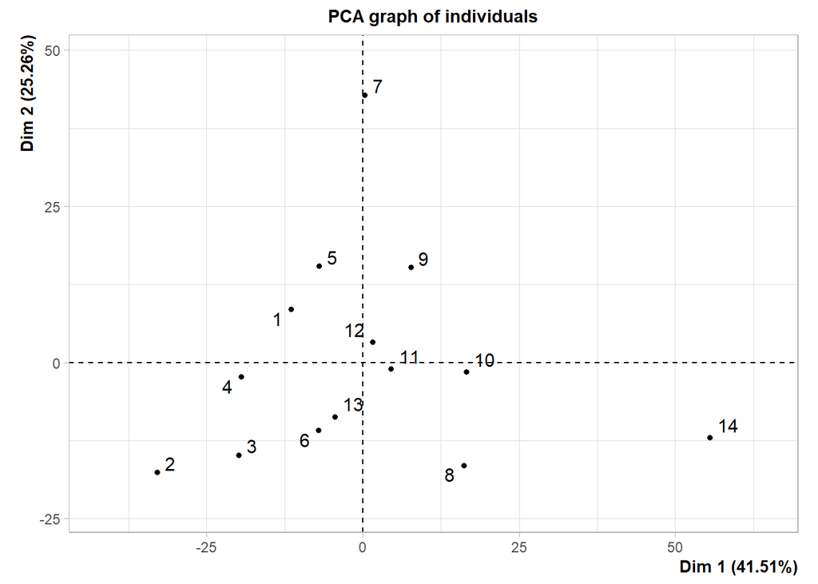

```r
res.pca.cov <- PCA(dados, scale.unit = F, graph = FALSE)
plot(res.pca.cov)
```

Quanto mais próxima uma variável for do círculo de correlações, melhor sua representação no mapa fatorial (e mais importante é a variável para a interpretação desses componentes) As variáveis próximas ao centro do gráfico são menos importantes para os primeiros componentes. No gráfico abaixo os componentes são coloridas de acordo com os valores do coseno quadrado: pela matriz covariancia:

# 11 pela matriz covariancia

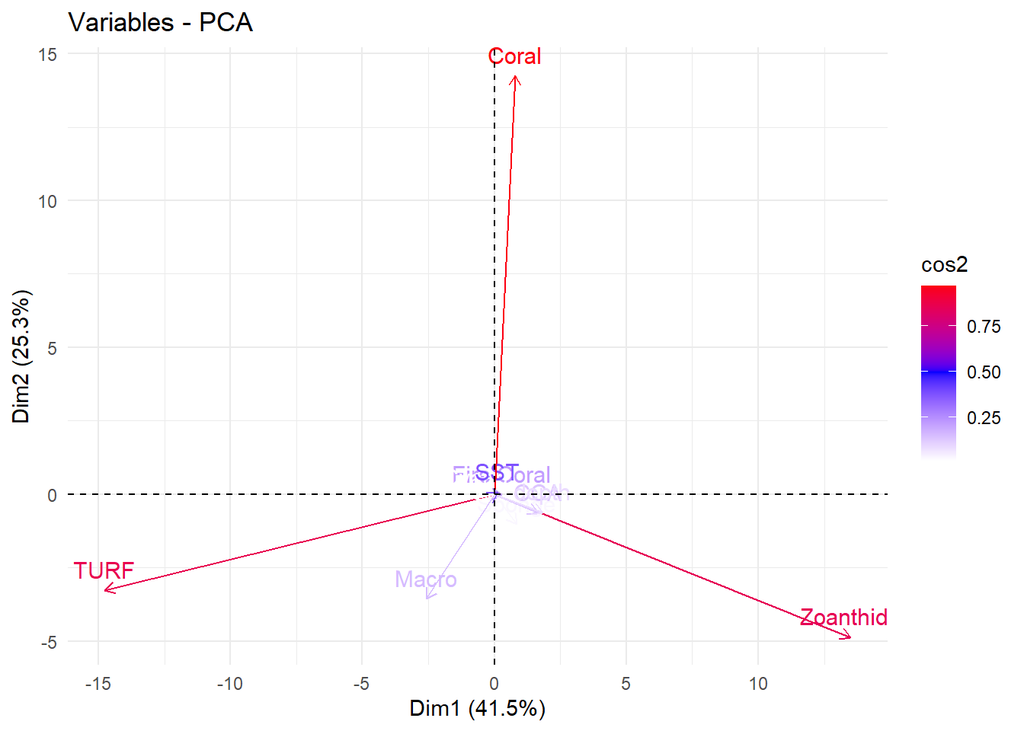

```r
fviz_pca_var(res.pca.cov, col.var="cos2") +
  scale_color_gradient2(low="white", mid="blue",
                        high="red", midpoint=0.5) + theme_minimal()
```

# 12 Proporção da variância explicada

verificando a partir da matriz de covariancia:

```r
R=cov(dados) # matriz de covar
l=eigen(R)$values   #autovalores
e=eigen(R)$vectors  #autovetores
```

# 13 Proporção explicada pra cada fator:

$l/sum(l)$ em que l=autovalor

```r
l/sum(l)
```

```
##  [1] 4.150885e-01 2.526202e-01 1.658898e-01 1.191720e-01 2.711136e-02
##  [6] 1.298761e-02 5.347709e-03 1.653137e-03 1.209337e-04 8.667081e-06
```

# 14 análise com mais fatores:

```r
l[1]/sum(l) # para analise com 1 fator
```

```
## [1] 0.4150885
```

```r
(l[1]+l[2])/sum(l)  # para analise com 2 fatores
```

```
## [1] 0.6677088
```

```r
(l[1]+l[2]+l[3])/sum(l) # para analise com 3 fatores
```

```
## [1] 0.8335986
```

```r
(l[1]+l[2]+l[3]+l[4])/sum(l) # para analise com 4 fatores
```

```
## [1] 0.9527706
```

```r
(l[1]+l[2]+l[3]+l[4]+l[5])/sum(l) # para analise com 5 fatores
```

```
## [1] 0.9798819
```

A proporção da variância explicada vai aumentando a medida que se aumenta o número de variáveis da análise e a soma se aproxima de 1 sempre que leva em consideração todas as variaveis do conjunto de dados